# project

I decide to use a new dataset different from the one used in hw3.

## About the Data

1. Name / Title: Trending videos on Youtube
2. Link to Data: https://www.kaggle.com/datasets/anushabellam/trending-videos-on-youtube
3. Source / Origin:
   - Author or Creator: Mendeley.com
   - Publication Date: 2022
   - Publisher: anusha bellam
   - Version or Data Accessed: 1
4. License: CC0: Public Domain
5. Can You Use this Data Set for Your Intended Use Case? Yes

## Format and Samples

### Overview

Format: csv Size: 73 KB Number of Records: 115

### Sample of Data

```python
import pandas as pd
import sys
file_path = sys.path[0] +'/../data/raw/Trending videos on youtube dataset.csv'

with open(file_path, 'r') as f:
    columns = f.readline().split(',')
    lines = f.readlines()
    first3lines = [tuple(line.split(',')) for line in lines][:3]

print('see first three lines of the dataset:')
for line in first3lines:
    print(line, '\n')
```

```
see first three lines of the dataset:
('0', 'UCU1_l0ZJyTK_7HZZ3Ruw8Dg', 'MAPS', 'pTnk3ziVVRM', '2014-01-10T01:24:57.000Z', 'Psychedelic Horizons Beyond Psychotherapy Workshop - Part 3/4', '"Watch the full workshop at http://psychedelicscience.org In addition to their psychotherapeutic uses', ' experimental evidence shows that psychedeli…

('1', 'UCLuO2lUqHrPIIpx0hFenV2g', 'Tink Tink Club', 'cuJjSeHZIrg', '2015-06-18T16:56:04.000Z', 'Episode 35 - Dr. James Fadiman', 'Dr. James Fadiman is the father of modern psychedelic therapy and the author of the Psychedelic Explorers Guide. He is currently doing research on the effects of microdos…

('2', 'UCihqrkaOgVMfLNo2W1hSliA', 'Podcast Bunk', 'IuyuZfWtGgg', '2016-05-01T05:33:13.000Z', '#325 Microdosing from The Adam and Dr Drew Show on podbay', '"Adam and Dr. Drew are solo today and they open the show talking to a caller about the new phenomenon of \'microdosing\' LSD and Drew gives his t…
```

### Fields or Column Headers

- column2', 'channelid'
- column3', 'channeltitle'
- column4', 'videoid'
- column5', 'publishedat'
- column6', 'videotitle'
- column7', 'videodescription'
- column8', 'videocategoryid'
- column9', 'videocategorylabel'
- column10', 'duration'
- column11', 'durationsec'
- column12', 'definition'
- column13', 'caption'
- column14', 'viewcount'
- column15', 'likecount'
- column16', 'dislikecount'
- column17', 'commentcount'

```python
[(f'column{i+1}',columns[i].lower()) for i in range(len(columns))]
```

```
[('column1', ''),
 ('column2', 'channelid'),
 ('column3', 'channeltitle'),
 ('column4', 'videoid'),
 ('column5', 'publishedat'),
 ('column6', 'videotitle'),
 ('column7', 'videodescription'),
 ('column8', 'videocategoryid'),
 ('column9', 'videocategorylabel'),
 ('column10', 'duration'),
 ('column11', 'durationsec'),
 ('column12', 'definition'),
 ('column13', 'caption'),
 ('column14', 'viewcount'),
 ('column15', 'likecount'),
 ('column16', 'dislikecount'),
 ('column17', 'commentcount\n')]
```

1. Retrieve the data, create a DataFrame
- Include the data for the graders by either:
  - downloading it and placing it into your data/raw directory
  - linking to it in a markdown cell
- Create a data frame from the data; use any method to do this (for example read_csv)

```python
import matplotlib.pyplot as plt
import numpy as np
```

```python
video = pd.read_csv(file_path, index_col = [0])
video
```

|  | channelId | channelTitle | videoId | publishedAt | videoTitle | videoDescription | videoCategoryId | videoCategoryLabel | duration | durationSec | definition | caption | viewCount | likeCount | dislikeCount | commentCount |
| --- | --- | --- | --- | --- | --- | --- | --- | --- | --- | --- | --- | --- | --- | --- | --- | --- |
| 0 | UCU1_l0ZJyTK_7HZZ3Ruw8Dg | MAPS | pTnk3ziVVRM | 2014-01-10T01:24:57.000Z | Psychedelic Horizons Beyond Psychotherapy Work... | Watch the full workshop at http://psychedelics... | 29 | Nonprofits & Activism | PT1H19M40S | 4780 | hd | False | 1512 | 8.0 | 0.0 | 1.0 |
| 1 | UCLuO2lUqHrPIIpx0hFenV2g | Tink Tink Club | cuJjSeHZIrg | 2015-06-18T16:56:04.000Z | Episode 35 - Dr. James Fadiman | Dr. James Fadiman is the father of modern psyc... | 22 | People & Blogs | PT1H12M34S | 4354 | sd | False | 881 | 14.0 | 0.0 | 3.0 |
| 2 | UCihqrkaOgVMfLNo2W1hSliA | Podcast Bunk | IuyuZfWtGgg | 2016-05-01T05:33:13.000Z | #325 Microdosing from The Adam and Dr Drew Sho... | Adam and Dr. Drew are solo today and they open... | 22 | People & Blogs | PT50M40S | 3040 | sd | False | 67 | 0.0 | 1.0 | 3.0 |
| 3 | UCgbWWPn3VYYzxjffZbfj9GQ | Alan Springwind | cng_ZhQf8iY | 2016-01-25T04:48:22.000Z | Microdosing Away The Same Old Blues | Source: https://www.spreaker.com/user/springwi... | 24 | Entertainment | PT32M21S | 1941 | hd | False | 4 | 0.0 | 0.0 | 0.0 |
| 4 | UCFmLi6X1mojkFZOFngNR9tQ | Drug Education Agency | OpQIQEx7J5A | 2014-08-15T10:53:58.000Z | Erschossener Kiffer / Drogen in Mikro-Dosierun... | Von erschossenen "Dealern", von demonstrierend... | 24 | Entertainment | PT26M32S | 1592 | hd | False | 5465 | 121.0 | 6.0 | 25.0 |
| ... | ... | ... | ... | ... | ... | ... | ... | ... | ... | ... | ... | ... | ... | ... | ... | ... |
| 110 | UCjnXuO6mfE0-czvcbOYnpbQ | Ayahuasca Magic | j9HFlDff2XY | 2016-03-25T04:58:34.000Z | Time differentials: mystery wisdom and microdo... | The lectures I talk about are free (some of th... | 24 | Entertainment | PT26M | 26 | hd | False | 304 | 6.0 | 0.0 | 22.0 |
| 111 | UC0dsjSDsLZ5hbmoNjvsHJsQ | fluidresearch | lOGAkCtT4wk | 2010-08-20T14:46:56.000Z | Fluid filling with exact precision dosing by F... | See how the industry leaders in Precision micr... | 26 | Howto & Style | PT18S | 18 | sd | False | 294 | 0.0 | 0.0 | 0.0 |
| 112 | UCmNZB3-zCyMuHCOTraws0dg | Helix Steel Victoria | sTNaGjt6564 | 2014-05-19T12:14:36.000Z | Accurate dosing of Helix Twisted Steel Micro R... | © Copyright --- Look at the steady rain of Hel... | 28 | Science & Technology | PT11S | 11 | hd | False | 463 | 0.0 | 0.0 | 0.0 |
| 113 | UC281yIVp-U8Ijg4KUVRgDRA | Osiron X | fMlQoGINGHo | 2016-04-15T19:31:48.000Z | Psilocybin Mushroom Micro-Dosing | When too much time lapses between trips, the e... | 24 | Entertainment | PT11M | 11 | sd | False | 341 | 11.0 | 1.0 | 10.0 |
| 114 | UCH4ezCqRXHQhsETfl0dainA | FabFormIndustries | ODX4tzCWhhU | 2015-08-19T18:25:20.000Z | Dosing Helix Micro Rebar | Coquitlam concrete goes into detail how they d... | 27 | Education | PT1M | 1 | hd | False | 345 | 4.0 | 0.0 | 0.0 |

115 rows × 16 columns

1. Using the Data
- In a markdown cell, describe what you'd like to use the data for:
  - repeat the same analysis that you did previously in plain python, but with pandas instead
  - perhaps you would simply like to clean it up for further analysis later
- Write code to achieve what you've written out above. The code should contain at least 4 (repetition is allowed) of the following:
  - 1 filling in missing values
  - 1 type conversion
  - 1 transform a column
  - 1 create a new calculated column
  - 1 visualization
  - 1 calculate summary statistics
  - 1 calculate value counts
- In a markdown cell above your code, write out which of the above requirements you're implementing. As you write your code, document your process in an accompanying markdown cell.

### Question 1:

When was the most video published in this dataset?

- Who (population): youtube viewers
- What (subject, discipline): youtube videos
- Where (location): online
- When (snapshot, longitudinal): not applicable
- How much data do you need to do the analysis/work: column 'publishedAt'

### Question 2:

- Who (population): youtube viewers
- What (subject, discipline): youtube videos
- Where (location): online
- When (snapshot, longitudinal): not applicable
- How much data do you need to do the analysis/work: column 'viewCount' of the dataset

### Question 3:

Is duration of the video correlated with view counts of videos?

- Who (population): youtube viewers
- What (subject, discipline): youtube videos
- Where (location): online
- When (snapshot, longitudinal): not applicable
- How much data do you need to do the analysis/work: column 'durationSec', 'viewCount' of the dataset

### Question 3:

Is video Category associated with video like counts?

- Who (population): youtube viewers
- What (subject, discipline): youtube videos
- Where (location): online
- When (snapshot, longitudinal): not applicable
- How much data do you need to do the analysis/work: column 'likeCount' and 'videoCategoryId'of the dataset

I transformed the "publishAt" column ty datetime type to get the year that has the most number of published video in the dataset.

```python
video.publishedAt = pd.to_datetime(video.publishedAt)
video.publishedAt.dt.year.value_counts()

print(f'Question1: year {video.publishedAt.dt.year.value_counts().index[0]} is the year that has the most number of published video in the dataset: \
    {video.publishedAt.dt.year.value_counts().values[0]} ')
```

[output not shown]

I used the value_counts() on the year attribute of the "publishedAt" columns, and then visualize it by making a bar plot of the count of videos published in each year.

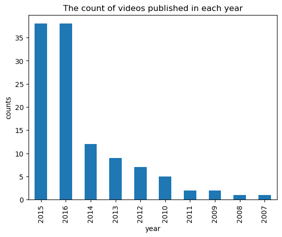

```python
video.publishedAt.dt.year.value_counts().plot.bar()
plt.title('The count of videos published in each year')
plt.xlabel('year')
plt.ylabel('counts')
plt.show()
```

I calculate summary statistics for the "viewCount" column of the dataset. I calculate its mean, median, min value, max value and standard deviation.

```python
mean = np.mean(video.viewCount)
median = np.median(video.viewCount)
min = video.viewCount.min()
max= video.viewCount.max()
std = np.std(video.viewCount)

print(f'Question2: summary statistics of view counts:\n \
    mean:{mean:.2f},\n \
    median:{median:.2f},\n \
    min:{min},\n \
    max:{max},\n \
    standard deviation:{std:.2f},\n')
```

```
Question2: summary statistics of view counts:
     mean:9164.05,
     median:356.00,
     min:2,
     max:526243,
     standard deviation:51784.62,
```

I fill out nan values in "likeCount", "dislikeCount", "commentCount" columns by replacing them with their means respectively.

```python
video.likeCount.fillna(video.likeCount.mean(), inplace = True)
video.dislikeCount.fillna(video.dislikeCount.mean(), inplace = True)
video.commentCount.fillna(video.commentCount.mean(), inplace = True)
```

I transform the "durationSec" column of the dataset from string to floats to see its correlation with view counts.

```python
video.durationSec = pd.to_numeric(video.durationSec, errors = 'coerce')
corr = video[['durationSec', 'viewCount']].corr()

print(f'Question3: The correlation between video duration and view counts is {corr.iloc[0, 1]:.4f}')
print('There does not seem to be a correlation between video duration and video view counts.')
```

```
Question3: The correlation between video duration and view counts is 0.0744
There does not seem to be a correlation between video duration and video view counts.
```

```python
corr = video[['videoCategoryId', 'likeCount']].corr()

print(f'Question4: the correlation between video category and like count is: {corr.iloc[0, 1]:.4f}')
print('There does not seem to be a correlation between video category and video like counts.')
```

```
Question4: the correlation between video category and like count is: 0.0720
There does not seem to be a correlation between video category and video like counts.
```

- 2 type conversion
  - I transformed the "publishAt" column ty datetime type to get the year that has the most number of published video in the dataset.
  - I transform the "durationSec" column of the dataset from string to floats to see its correlation with view counts.
- 1 calculate value counts, 1 visualization
  - I used the value_counts() on the year attribute of the "publishedAt" columns
  - I visualize it by making a bar plot of the count of videos published in each year.
- 1 calculate summary statistics
  - I calculate summary statistics for the "viewCount" column of the dataset. I calculate its mean, median, min value, max value and standard deviation.
- 1 filling in missing values
  - I fill out nan values in "likeCount", "dislikeCount", "commentCount" columns by replacing them with thir means respectively.